# Machine Learning Project - Weight Lifting Dataset

Author: melancurion September 2015

## Synopsis

This report summarizes the design decisions, execution, and results of a prediction analysis based on the Weight Lifting Dataset described at the following URL:

http://groupware.les.inf.puc-rio.br/har#weight_lifting_exercises

The purpose of this exercise is to predict the predict the manner in which 6 participants in the cited Human Activity Recognition trial did the exercise, based on data from accelerometers on their belt, forearm, arm, and dumbell. They were asked to perform Unilateral Dumbbell Biceps Curl correctly and incorrectly in 5 different ways, as summarized below:

- exactly according to the specification (Class A)
- throwing the elbows to the front (Class B)
- lifting the dumbbell only halfway (Class C)
- lowering the dumbbell only halfway (Class D)
- throwing the hips to the front (Class E).

The prediction takes the form of the appropriate character identifier (A, B, C, D, or E) for each of the 20 test cases included in the *testing* dataset, from which the ‘classe’ variable has been omitted. The *training* dataset includes the ‘classe’ values for all observations.

The *training* and *testing* datasets were pre-allocated prior to commencement of this exercise. These are available respectively at

https://d396qusza40orc.cloudfront.net/predmachlearn/pml-training.csv and

https://d396qusza40orc.cloudfront.net/predmachlearn/pml-testing.csv

The full dataset of which these *training* and *testing* datasets are subsets is available at

http://groupware.les.inf.puc-rio.br/static/WLE/WearableComputing_weight_lifting_exercises_biceps_curl_variations.csv

## Prediction Study Design

### Performance targets

We elect to set the target prediction parameters as follows:

- Total accuracy: 0.99 or better
- Type I and Type II error rates: 0.01 or better

### Data split

The provided test set consists of 20 records only. The training dataset contains (19622 records). The validation dataset will be used to obtain an unbiased out-of-sample prediction error estimate prior to application to the test set.

### Partition data

The original training dataset is partitioned into “training” and “validation” subsets in the ratio 60:40. We will apply four-fold cross-validation.

### Examine data

The ‘classe’ variable in the raw training dataset has the follwing frequencies: 5580, 3797, 3422, 3216, 3607.

Visualizations of the predictor variables are shown in a subsequent section (following normalization).

### Training variable selection

#### Ascertain columns containing missing values

To avoid model fitting difficulties due to missing predictor values, those columns for which the proportion of missing values exceeds 5% are dropped.

This operation reduces the number of candidate variables by 100 to a total of 60.

### Remove identifiers and timestamps

We assume that the observation time and sequence does not influence the outcome. The following are not predictor candidates, hence will be removed from the training data:

- ‘X’
- ‘user_name’
- ‘raw_timestamp_part_1’
- ‘raw_timestamp_part_2’
- ‘cvtd_timestamp’

### Determine and exclude variables with near zero variance

The near zero variance status of all remaining variables is tabulated below. It is evident that any such variables have been excluded by earlier cuts, hence this list constitutes the finalized set of variables. All variables listed except ‘classe’ (the outcome variable) will be modelled as predictors.

```
##                      freqRatio percentUnique zeroVar   nzv
## roll_belt             1.210630    8.70414402   FALSE FALSE
## pitch_belt            1.000000   13.80774457   FALSE FALSE
## yaw_belt              1.035144   14.53804348   FALSE FALSE
## total_accel_belt      1.054900    0.23777174   FALSE FALSE
## gyros_belt_x          1.025516    1.12092391   FALSE FALSE
## gyros_belt_y          1.120337    0.53498641   FALSE FALSE
## gyros_belt_z          1.063970    1.32472826   FALSE FALSE
## accel_belt_x          1.091106    1.34171196   FALSE FALSE
## accel_belt_y          1.105033    1.14639946   FALSE FALSE
## accel_belt_z          1.101504    2.42017663   FALSE FALSE
## magnet_belt_x         1.150000    2.57302989   FALSE FALSE
## magnet_belt_y         1.072319    2.39470109   FALSE FALSE
## magnet_belt_z         1.099644    3.63451087   FALSE FALSE
## roll_arm             49.292683   19.41236413   FALSE FALSE
## pitch_arm            77.769231   22.48641304   FALSE FALSE
## yaw_arm              28.464789   21.42493207   FALSE FALSE
## total_accel_arm       1.033272    0.55197011   FALSE FALSE
## gyros_arm_x           1.039344    5.29891304   FALSE FALSE
## gyros_arm_y           1.488294    3.07404891   FALSE FALSE
## gyros_arm_z           1.083851    1.97860054   FALSE FALSE
## accel_arm_x           1.009259    6.45380435   FALSE FALSE
## accel_arm_y           1.080000    4.41576087   FALSE FALSE
## accel_arm_z           1.066667    6.47078804   FALSE FALSE
## magnet_arm_x          1.094340   11.13281250   FALSE FALSE
## magnet_arm_y          1.000000    7.20957880   FALSE FALSE
## magnet_arm_z          1.029851   10.57235054   FALSE FALSE
## roll_dumbbell         1.011111   87.44055707   FALSE FALSE
## pitch_dumbbell        2.054945   85.33457880   FALSE FALSE
## yaw_dumbbell          1.123457   86.75271739   FALSE FALSE
## total_accel_dumbbell  1.043531    0.35665761   FALSE FALSE
## gyros_dumbbell_x      1.013966    1.93614130   FALSE FALSE
## gyros_dumbbell_y      1.182825    2.22486413   FALSE FALSE
## gyros_dumbbell_z      1.008021    1.63043478   FALSE FALSE
## accel_dumbbell_x      1.132979    3.44769022   FALSE FALSE
## accel_dumbbell_y      1.012903    3.83831522   FALSE FALSE
## accel_dumbbell_z      1.111842    3.40523098   FALSE FALSE
## magnet_dumbbell_x     1.200000    8.71263587   FALSE FALSE
## magnet_dumbbell_y     1.203540    6.86141304   FALSE FALSE
## magnet_dumbbell_z     1.052632    5.57914402   FALSE FALSE
## roll_forearm         11.700000   14.78430707   FALSE FALSE
## pitch_forearm        61.578947   20.96637228   FALSE FALSE
## yaw_forearm          15.000000   13.97758152   FALSE FALSE
## total_accel_forearm   1.124834    0.58593750   FALSE FALSE
## gyros_forearm_x       1.074675    2.35224185   FALSE FALSE
## gyros_forearm_y       1.022727    5.99524457   FALSE FALSE
## gyros_forearm_z       1.148551    2.32676630   FALSE FALSE
## accel_forearm_x       1.068966    6.55570652   FALSE FALSE
## accel_forearm_y       1.031250    8.19463315   FALSE FALSE
## accel_forearm_z       1.000000    4.61956522   FALSE FALSE
## magnet_forearm_x      1.040816   12.03294837   FALSE FALSE
## magnet_forearm_y      1.169492   15.22588315   FALSE FALSE
## magnet_forearm_z      1.027778   13.40862772   FALSE FALSE
## classe                1.469065    0.04245924   FALSE FALSE
```

### Align validation and final test data with training data

The validation and testing data are subsetted to include only those variables that exist in the finalized parameter set for the training data (excluding ‘classe’).

### Normalization

Numeric data are centered and scaled via the caret preProcess function. The normalization is not strictly necessary for model generation in this case, but allows more intuitive comparison of variable distributions in the visualization plots.

### Visualization

Plots of pairwise relationships for the 52 predictor variables seem to provide more confusion than insight. For each level of `classe` in the training data we instead elect to represent the distribution of each *normalized* predictor in the form of lattice boxplots. These are arrayed in two grids for ease of presentation.

#### Predictors 1 - 26

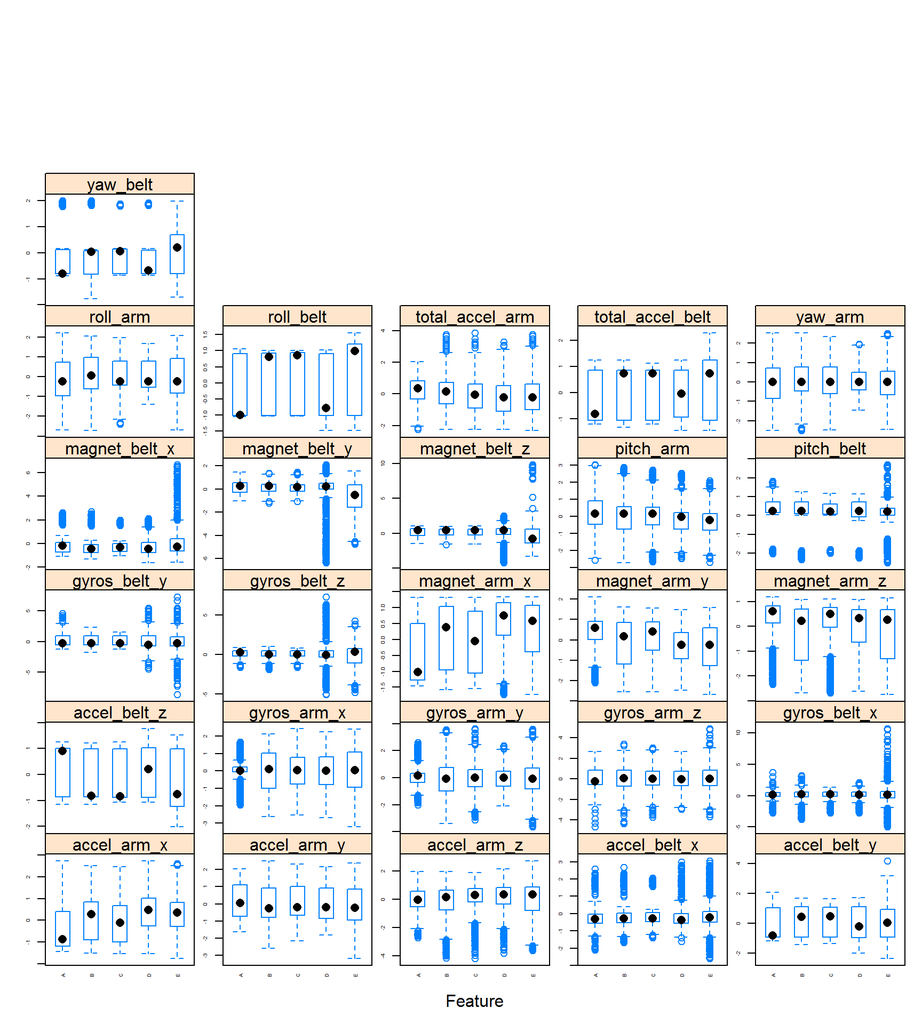

#### Predictors 27 - 52

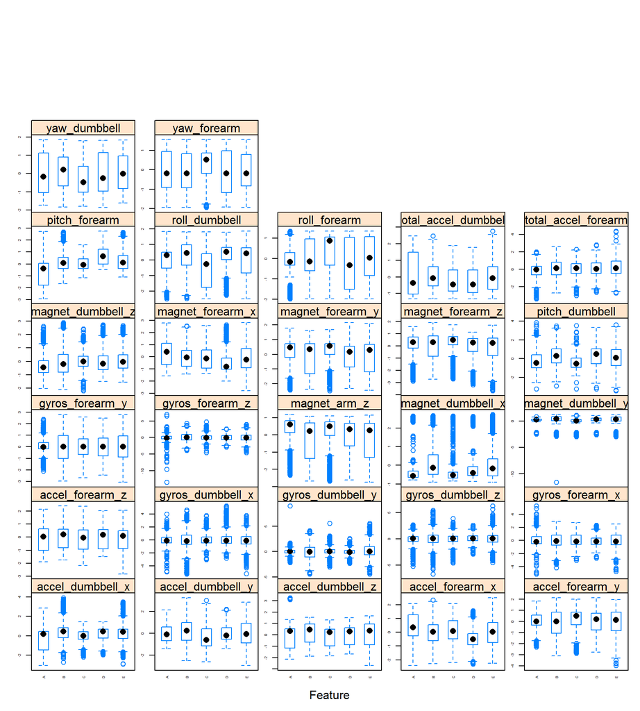

## Model selection

Given the relatively large number of predictors, it is not intuitively obvious which are likely to prove significant. An algorithm that self-selects the most important predictors from the candidate set, such as Random Forest, is therefore attractive. This will be applied with 4-fold cross-validation.

### Error estimates

#### In-sample statistics

```
## Confusion Matrix and Statistics
##
##           Reference
## Prediction    A    B    C    D    E
##          A 3348    0    0    0    0
##          B    0 2279    0    0    0
##          C    0    0 2054    0    0
##          D    0    0    0 1930    0
##          E    0    0    0    0 2165
##
## Overall Statistics
##
##                Accuracy : 1
##                  95% CI : (0.9997, 1)
##     No Information Rate : 0.2843
##     P-Value [Acc > NIR] : < 2.2e-16
##
##                   Kappa : 1
##  Mcnemar's Test P-Value : NA
##
## Statistics by Class:
##
##                      Class: A Class: B Class: C Class: D Class: E
## Sensitivity            1.0000   1.0000   1.0000   1.0000   1.0000
## Specificity            1.0000   1.0000   1.0000   1.0000   1.0000
## Pos Pred Value         1.0000   1.0000   1.0000   1.0000   1.0000
## Neg Pred Value         1.0000   1.0000   1.0000   1.0000   1.0000
## Prevalence             0.2843   0.1935   0.1744   0.1639   0.1838
## Detection Rate         0.2843   0.1935   0.1744   0.1639   0.1838
## Detection Prevalence   0.2843   0.1935   0.1744   0.1639   0.1838
## Balanced Accuracy      1.0000   1.0000   1.0000   1.0000   1.0000
```

The actual in-sample error rate for the *training* data is 0%.

#### Cross-validation accuracy by number of predictors

The following plot shows the relationship between the number of predictors randomly selected by the algorithm and the accuracy determined during cross-validation. Although no fine-grained detail is available, it seems that maximum accuracy is obtained where about half of the 52 predictors are used, and that the rest of the predictors increase the noise.

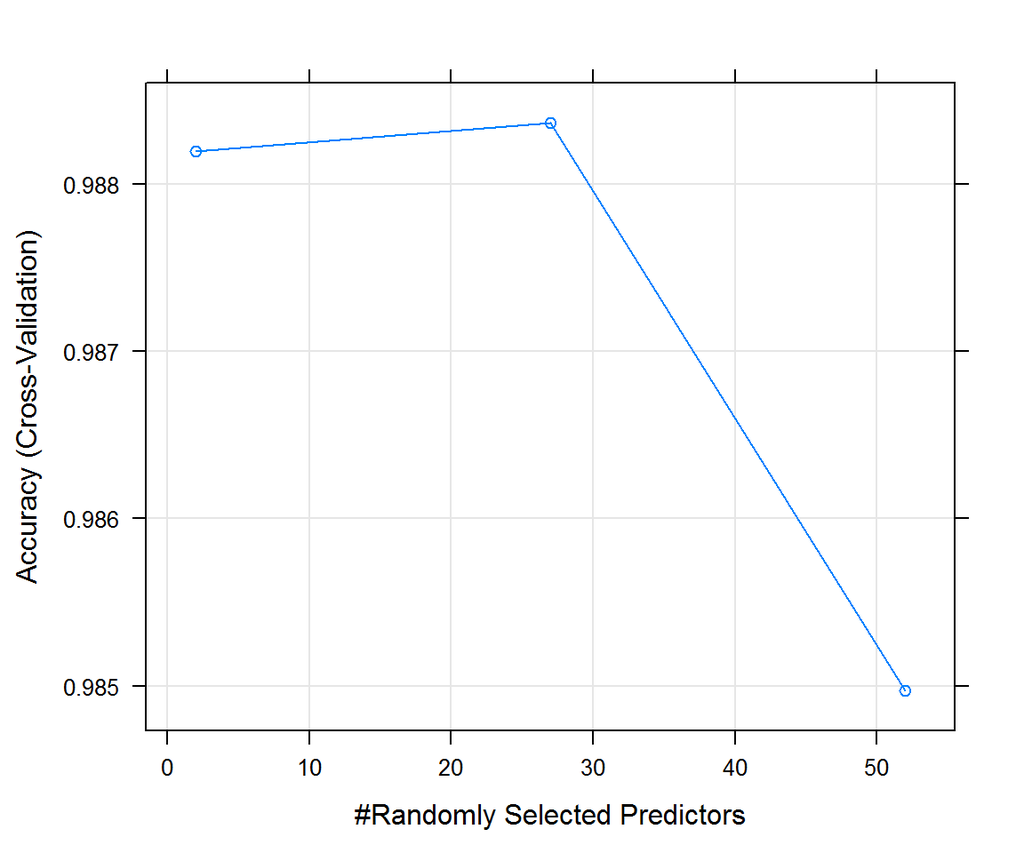

#### Relative importance of predictors

The following plot shows the relative importance of each predictor, as determined by the model fit.

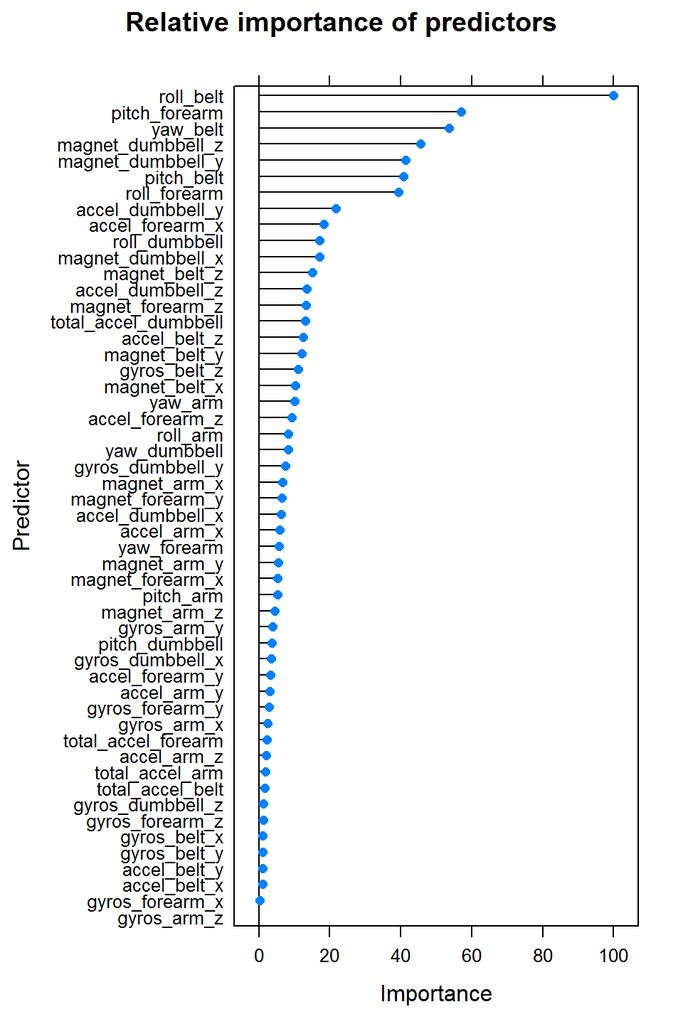

#### Out-of-sample error rate estimates based on validation dataset

The following statistics result from application of the model (trained and cross-validated on the training data) to the validation set.

```
## Confusion Matrix and Statistics
##
##           Reference
## Prediction    A    B    C    D    E
##          A 2229    2    0    0    1
##          B   12 1495    7    4    0
##          C    0    3 1363    2    0
##          D    0    0   20 1264    2
##          E    0    0    1    6 1435
##
## Overall Statistics
##
##                Accuracy : 0.9924
##                  95% CI : (0.9902, 0.9942)
##     No Information Rate : 0.2856
##     P-Value [Acc > NIR] : < 2.2e-16
##
##                   Kappa : 0.9903
##  Mcnemar's Test P-Value : NA
##
## Statistics by Class:
##
##                      Class: A Class: B Class: C Class: D Class: E
## Sensitivity            0.9946   0.9967   0.9799   0.9906   0.9979
## Specificity            0.9995   0.9964   0.9992   0.9967   0.9989
## Pos Pred Value         0.9987   0.9848   0.9963   0.9829   0.9951
## Neg Pred Value         0.9979   0.9992   0.9957   0.9982   0.9995
## Prevalence             0.2856   0.1912   0.1773   0.1626   0.1833
## Detection Rate         0.2841   0.1905   0.1737   0.1611   0.1829
## Detection Prevalence   0.2845   0.1935   0.1744   0.1639   0.1838
## Balanced Accuracy      0.9971   0.9965   0.9895   0.9936   0.9984
```

## Predictions on test set

The model is applied to the testing dataset to generate predictions for submission. The following results were obtained, corresponding to Problem ID 1 through 20

```
##  [1] B A B A A E D B A A B C B A E E A B B B
## Levels: A B C D E
```

## References

Velloso, E.; Bulling, A.; Gellersen, H.; Ugulino, W.; Fuks, H. Qualitative Activity Recognition of Weight Lifting Exercises. Proceedings of 4th International Conference in Cooperation with SIGCHI (Augmented Human ’13) . Stuttgart, Germany: ACM SIGCHI, 2013.

Read more: http://groupware.les.inf.puc-rio.br/har#weight_lifting_exercises#ixzz3mYc33R40